# credit_system2

```python
import os

# Cambiar al directorio correcto
os.chdir('/Users/alex/Library/CloudStorage/GoogleDrive-arodriguezjus@uoc.edu/My Drive/1 UOC/00_SEMESTRE/Diseño producto de datos/git')
```

```python
import warnings
warnings.filterwarnings('ignore')

import pandas as pd
import matplotlib.pyplot as plt
import numpy as np
import matplotlib.pyplot as plt
import seaborn as sns
import pandas as pd
from sklearn.impute import SimpleImputer
from sklearn.preprocessing import StandardScaler, LabelEncoder
from imblearn.over_sampling import SMOTE

# Configurar gráficos en línea
%matplotlib inline

# Cargar los archivos CSV
transactions = pd.read_csv('data/data_BOC_transactions.csv')
credit_risk = pd.read_csv('data/data_BOC_creditRisk.csv')
fraud_detection = pd.read_csv('data/data_BOC_fraudDetection.csv')
```

## Analisis exploratorio, limpieza y preprocesamiento de Datos

### Analisis exploratorio - data_BOC_transactions.csv

```python
# Mostrar las primeras filas de cada dataframe
transactions.head()
```

|  | TransactionID | CustomerID | CustomerBirth | CustomerGender | TransactionLocation | TransactionDate | TransactionAmount (eur) | otherActor |
| --- | --- | --- | --- | --- | --- | --- | --- | --- |
| 0 | T1 | C5841053 | 10/1/94 | F | Viana do Castelo | 2/8/16 | 25.0 | C1419665 |
| 1 | T2 | C2142763 | 4/4/57 | M | Coria del Río | 2/8/16 | 27999.0 | NaN |
| 2 | T3 | C4417068 | 26/11/96 | F | Jávea | 2/8/16 | 459.0 | C3467392 |
| 3 | T4 | C5342380 | 14/9/73 | F | Córdoba | 2/8/16 | 2060.0 | C6628470 |
| 4 | T5 | C9031234 | 24/3/88 | F | Sestao | 2/8/16 | 1762.5 | C7321714 |

```python
print("Información General de Transacciones:\n")
print(transactions.info())
```

```
Información General de Transacciones:

<class 'pandas.core.frame.DataFrame'>
RangeIndex: 1048567 entries, 0 to 1048566
Data columns (total 8 columns):
 #   Column                   Non-Null Count    Dtype
---  ------                   --------------    -----
 0   TransactionID            1048567 non-null  object
 1   CustomerID               1048567 non-null  object
 2   CustomerBirth            1045170 non-null  object
 3   CustomerGender           1047467 non-null  object
 4   TransactionLocation      1048567 non-null  object
 5   TransactionDate          1048567 non-null  object
 6   TransactionAmount (eur)  1048567 non-null  float64
 7   otherActor               419567 non-null   object
dtypes: float64(1), object(7)
memory usage: 64.0+ MB
None
```

```python
# TransactionAmount (eur)
transactions.describe()
```

|  | TransactionAmount (eur) |
| --- | --- |
| count | 1.048567e+06 |
| mean | 3.103965e+02 |
| std | 6.753476e+03 |
| min | -1.560035e+06 |
| 25% | -2.700000e+02 |
| 50% | 1.000000e+02 |
| 75% | 6.000000e+02 |
| max | 6.000083e+05 |

```python
# Verificar valores nulos
print("Valores Nulos en Transacciones % :")
print(transactions.isnull().mean() * 100)
```

```
Valores Nulos en Transacciones % :
TransactionID               0.000000
CustomerID                  0.000000
CustomerBirth               0.323966
CustomerGender              0.104905
TransactionLocation         0.000000
TransactionDate             0.000000
TransactionAmount (eur)     0.000000
otherActor                 59.986629
dtype: float64
```

La gran cantidad de valores nulos en otherActor sugiere que muchas transacciones son unilaterales o que no se registró correctamente el otro actor involucrado. Los valores nulos en CustomerBirth y CustomerGender necesitarán imputación o eliminación, dependiendo de su relevancia para el análisis de riesgo crediticio.

- otherActor: hay una cantidad significativa de transacciones sin un actor contrario (otherActor).
- CustomerBirth y `CustomerGender: Algunas transacciones carecen de información sobre la fecha de nacimiento y el género del cliente, pero estos valores nulos son relativamente pequeños en comparación con el total de registros.
- TransactionAmount (eur): Los valores varían ampliamente, indicando una diversidad en el tamaño de las transacciones.

### Analisis exploratorio - data_BOC_creditRisk.csv

```python
# Riesgo de Crédito
credit_risk.head()
```

|  | Job | Housing | Credit amount | Duration | Purpose | Risk | CustomerID |
| --- | --- | --- | --- | --- | --- | --- | --- |
| 0 | 2 | own | 1169 | 6 | radio/TV | good | C1938652 |
| 1 | 2 | own | 5951 | 48 | radio/TV | bad | C8016323 |
| 2 | 1 | own | 2096 | 12 | education | good | C5141487 |
| 3 | 2 | free | 7882 | 42 | furniture/equipment | good | C7035854 |
| 4 | 2 | free | 4870 | 24 | car | bad | C5442952 |

```python
print("Información General de Riesgo de Crédito:\n")
print(credit_risk.info())
```

```
Información General de Riesgo de Crédito:

<class 'pandas.core.frame.DataFrame'>
RangeIndex: 1000 entries, 0 to 999
Data columns (total 7 columns):
 #   Column         Non-Null Count  Dtype
---  ------         --------------  -----
 0   Job            1000 non-null   int64
 1   Housing        1000 non-null   object
 2   Credit amount  1000 non-null   int64
 3   Duration       1000 non-null   int64
 4   Purpose        1000 non-null   object
 5   Risk           1000 non-null   object
 6   CustomerID     1000 non-null   object
dtypes: int64(3), object(4)
memory usage: 54.8+ KB
None
```

```python
credit_risk.describe()
```

|  | Job | Credit amount | Duration |
| --- | --- | --- | --- |
| count | 1000.000000 | 1000.000000 | 1000.000000 |
| mean | 1.904000 | 3271.258000 | 20.903000 |
| std | 0.653614 | 2822.736876 | 12.058814 |
| min | 0.000000 | 250.000000 | 4.000000 |
| 25% | 2.000000 | 1365.500000 | 12.000000 |
| 50% | 2.000000 | 2319.500000 | 18.000000 |
| 75% | 2.000000 | 3972.250000 | 24.000000 |
| max | 3.000000 | 18424.000000 | 72.000000 |

```python
# Verificar valores nulos
print("\nValores Nulos en Riesgo de Crédito % :")
print(credit_risk.isnull().mean() * 100)
```

```
Valores Nulos en Riesgo de Crédito % :
Job              0.0
Housing          0.0
Credit amount    0.0
Duration         0.0
Purpose          0.0
Risk             0.0
CustomerID       0.0
dtype: float64
```

**Datos de Riesgo de Crédito (data_BOC_creditRisk.csv):**  
Total de registros: 1,000 . No hay valores nulos.

- Job, Housing, Credit amount, Duration, Purpose, Risk: Estos campos están bien definidos y completos.
- Risk: La variable de riesgo contiene las etiquetas good y bad, que son cruciales para el modelo de evaluación de crédito.

### Analisis exploratorio - data_BOC_fraudDetection.csv

```python
# Detección de Fraude
fraud_detection.head()
```

|  | type | amount | Orig | oldbalanceOrig | newbalanceOrig | Dest | oldbalanceDest | newbalanceDest | isFraud |
| --- | --- | --- | --- | --- | --- | --- | --- | --- | --- |
| 0 | PAYMENT | 9839.64 | C4241584 | 170136.0 | 160296.36 | C7814776 | 0.0 | 0.0 | 0 |
| 1 | PAYMENT | 1864.28 | C7332525 | 21249.0 | 19384.72 | C7821866 | 0.0 | 0.0 | 0 |
| 2 | TRANSFER | 181.00 | NaN | 181.0 | 0.00 | C5821867 | 0.0 | 0.0 | 1 |
| 3 | CASH_OUT | 181.00 | C8442079 | 181.0 | 0.00 | C8831669 | 21182.0 | 0.0 | 1 |
| 4 | PAYMENT | 11668.14 | C3359562 | 41554.0 | 29885.86 | NaN | 0.0 | 0.0 | 0 |

```python
print("Información General de Detección de Fraude:\ ")
fraud_detection.info()
```

```
Información General de Detección de Fraude:\
<class 'pandas.core.frame.DataFrame'>
RangeIndex: 100000 entries, 0 to 99999
Data columns (total 9 columns):
 #   Column          Non-Null Count   Dtype
---  ------          --------------   -----
 0   type            100000 non-null  object
 1   amount          100000 non-null  float64
 2   Orig            75000 non-null   object
 3   oldbalanceOrig  100000 non-null  float64
 4   newbalanceOrig  100000 non-null  float64
 5   Dest            75000 non-null   object
 6   oldbalanceDest  100000 non-null  float64
 7   newbalanceDest  100000 non-null  float64
 8   isFraud         100000 non-null  int64
dtypes: float64(5), int64(1), object(3)
memory usage: 6.9+ MB
```

```python
fraud_detection.describe()
```

|  | amount | oldbalanceOrig | newbalanceOrig | oldbalanceDest | newbalanceDest | isFraud |
| --- | --- | --- | --- | --- | --- | --- |
| count | 1.000000e+05 | 1.000000e+05 | 1.000000e+05 | 1.000000e+05 | 1.000000e+05 | 100000.000000 |
| mean | 1.736022e+05 | 8.777575e+05 | 8.940619e+05 | 8.805048e+05 | 1.184041e+06 | 0.001160 |
| std | 3.443003e+05 | 2.673284e+06 | 2.711318e+06 | 2.402267e+06 | 2.802350e+06 | 0.034039 |
| min | 3.200000e-01 | 0.000000e+00 | 0.000000e+00 | 0.000000e+00 | 0.000000e+00 | 0.000000 |
| 25% | 9.963562e+03 | 0.000000e+00 | 0.000000e+00 | 0.000000e+00 | 0.000000e+00 | 0.000000 |
| 50% | 5.274552e+04 | 2.006150e+04 | 0.000000e+00 | 2.083943e+04 | 4.990918e+04 | 0.000000 |
| 75% | 2.117631e+05 | 1.901920e+05 | 2.148132e+05 | 5.882724e+05 | 1.058186e+06 | 0.000000 |
| max | 1.000000e+07 | 3.379739e+07 | 3.400874e+07 | 3.400874e+07 | 3.894623e+07 | 1.000000 |

```python
# Verificar valores nulos
print("\nValores Nulos en Detección de Fraude % :")
print(fraud_detection.isnull().mean() * 100)
```

```
Valores Nulos en Detección de Fraude % :
type               0.0
amount             0.0
Orig              25.0
oldbalanceOrig     0.0
newbalanceOrig     0.0
Dest              25.0
oldbalanceDest     0.0
newbalanceDest     0.0
isFraud            0.0
dtype: float64
```

**Datos de Detección de Fraude (data_BOC_fraudDetection.csv):**  
Total de registros: 100,000 , **Orig**: 25% nulos , **Dest**: 25% nulos

Los valores nulos en Orig y Dest indican que una cantidad significativa de transacciones no tiene identificadores claros de origen y destino, lo que puede complicar el análisis de fraude. La baja incidencia de fraude **isFraud** requiere técnicas específicas para manejar el desbalanceo de clases en el modelo de detección de fraude.

- Orig y Dest: Una cuarta parte de los registros carecen de información sobre el origen y destino de las transacciones, lo cual es significativo.
- isFraud: Contiene etiquetas binarias indicando si una transacción es fraudulenta o no, con una incidencia muy baja de fraude (0.116% de las transacciones).

### Limpieza y preprocesamiento de datos

- **Eliminación de Duplicados**: Identificar y eliminar registros duplicados.
- **Manejo de Valores Faltantes**: Imputación o eliminación de valores nulos o faltantes.
- **Conversión de Tipos de Datos**: Asegurar que los tipos de datos sean consistentes para análisis y modelado.
- **Normalización y Estandarización**: Escalado de variables numéricas para su uso en modelos.

```python
# Cargar los archivos CSV
df_transactions = transactions.copy()
df_credit_risk = credit_risk.copy()
df_fraud_detection = fraud_detection.copy()
```

Datos duplicados

```python
# Verificar si hay instancias duplicadas
duplicated_rows = df_transactions.duplicated()
print("Número de filas duplicadas en df_transactions:", duplicated_rows.sum())

# Verificar si hay instancias duplicadas
duplicated_rows = df_credit_risk.duplicated()
print("Número de filas duplicadas en df_duplicated_rows:", duplicated_rows.sum())

# Verificar si hay instancias duplicadas
duplicated_rows = df_fraud_detection.duplicated()
print("Número de filas duplicadas en df_fraud_detection:", duplicated_rows.sum())
```

```
Número de filas duplicadas en df_transactions: 0
Número de filas duplicadas en df_duplicated_rows: 0
Número de filas duplicadas en df_fraud_detection: 0
```

#### **df_transactions**

Variables Explicativas (Features)

- **TransactionAmount (eur)**: Monto de la transacción.
- **TransactionLocation**: Localización de la transacción.
- **CustomerGender**: Género del cliente.
- **CustomerBirth**: Fecha de nacimiento del cliente.
- **TransactionDate**: Fecha de la transacción.

Variables Objetivo (Targets)

- **TransactionAmount (eur)**: Puede ser utilizada tanto como feature en análisis predictivo o target en análisis de series temporales para pronosticar transacciones futuras.

```python
df_transactions.shape
```

```
(1048567, 8)
```

**df_transactions['CustomerGender']**

```python
print(df_transactions['CustomerGender'].unique())
```

```
['F' 'M' nan 'T']
```

```python
df_transactions['CustomerGender'].value_counts(dropna=False)
```

```
CustomerGender
M      765530
F      281936
NaN      1100
T           1
Name: count, dtype: int64
```

```python
# Crear una nueva categoría "Unknown" para los valores nulos en CustomerGender
df_transactions['CustomerGender'] = df_transactions['CustomerGender'].fillna('Unknown')

# Eliminar la fila con 'T' en 'CustomerGender'
df_transactions = df_transactions[df_transactions['CustomerGender'] != 'T']

# Verificar la imputación
print(f"Valores nulos en 'CustomerGender' : {df_transactions['CustomerGender'].isnull().sum()} \n")
print(df_transactions['CustomerGender'].unique())
```

```
Valores nulos en 'CustomerGender' : 0

['F' 'M' 'Unknown']
```

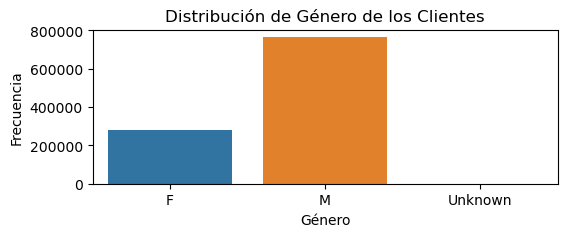

```python
# Análisis de CustomerGender
plt.figure(figsize=(6, 2))
sns.countplot(data=df_transactions, x='CustomerGender')
plt.title('Distribución de Género de los Clientes')
plt.xlabel('Género')
plt.ylabel('Frecuencia')
plt.show()
```

```python
# Ahora realizamos la codificación One-Hot
df_transactions_encoded = pd.get_dummies(df_transactions, columns=['CustomerGender'])
df_transactions_encoded.head()
```

|  | TransactionID | CustomerID | CustomerBirth | TransactionLocation | TransactionDate | TransactionAmount (eur) | otherActor | CustomerGender_F | CustomerGender_M | CustomerGender_Unknown |
| --- | --- | --- | --- | --- | --- | --- | --- | --- | --- | --- |
| 0 | T1 | C5841053 | 10/1/94 | Viana do Castelo | 2/8/16 | 25.0 | C1419665 | True | False | False |
| 1 | T2 | C2142763 | 4/4/57 | Coria del Río | 2/8/16 | 27999.0 | NaN | False | True | False |
| 2 | T3 | C4417068 | 26/11/96 | Jávea | 2/8/16 | 459.0 | C3467392 | True | False | False |
| 3 | T4 | C5342380 | 14/9/73 | Córdoba | 2/8/16 | 2060.0 | C6628470 | True | False | False |
| 4 | T5 | C9031234 | 24/3/88 | Sestao | 2/8/16 | 1762.5 | C7321714 | True | False | False |

**df_transactions['CustomerGender']**

- La codificación One-Hot convierte la columna CustomerGender en varias columnas binarias, permitiendo que los modelos de machine learning utilicen estas categorías sin suponer una relación ordinal entre ellas. Este paso es esencial para preparar adecuadamente los datos categóricos antes de entrenar un modelo de machine learning.
- En las 1048567 instancias tenemos un caso con el atributo "**T**" que no proporciona información suficiente y no es significativa, eliminamos la fila.
- Para los valores **nan**, creo una nueva categoría "Desconocido", esto evita hacer suposiciones y mantiene la integridad de los datos originales.

**df_transactions['otherActor']**

En este caso, a falta de tener acceso a la funte de los datos, vamos a interpretar 'otherActor' como el ID de otra persona o entidad que participa en la transacción, como un vendedor, un beneficiario o un socio comercial.

```python
non_null_other_actor = df_transactions['otherActor'].notnull().sum()
total_entries = df_transactions.shape[0]
print(f"Total entries: {total_entries}")
print(f"Entries with non-null otherActor: {non_null_other_actor}")

unique_other_actors = df_transactions['otherActor'].nunique()
print(f"Unique values in otherActor: {unique_other_actors}")
```

[output not shown]

**En caso del emisor y receptor en df_transactions['TransactionAmount (eur)'] :**

Podemos apreciar que existen transacciones positivas y negativas (emitidas y recibidas), es decir, pagos e ingresos en cuenta. Por otra parte tenemos el CustomerID de la cuenta y tenemos el 'otherActor' que lo interpretamos como la otra entidad que participa en la transacción, es decir el receptor o emisor dependiendo si la transacción es + ó (-).

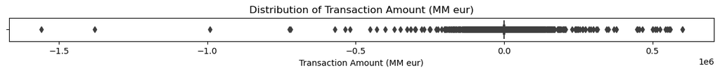

```python
# Crear el boxplot horizontal
plt.figure(figsize=(15, 0.5))
sns.boxplot(x='TransactionAmount (eur)', data=df_transactions, orient='h')

# Etiquetas y título del gráfico
plt.xlabel('Transaction Amount (MM eur)')
plt.title('Distribution of Transaction Amount (MM eur)')
plt.show()
```

Vamos a transformar el dataset para separar claramente el EmitterID (ID del emisor) y ReceiverID (ID del receptor), de esta forma se hace más fácil realizar análisis y modelos predictivos sin tener que reinterpretar continuamente el significado de TransactionAmount (eur).

```python
# Crear nuevas columnas EmitterID y ReceiverID basadas en el valor de TransactionAmount (eur)
df_transactions['EmitterID'] = df_transactions.apply(lambda row: row['CustomerID'] if row['TransactionAmount (eur)'] < 0 else row['otherActor'], axis=1)
df_transactions['ReceiverID'] = df_transactions.apply(lambda row: row['CustomerID'] if row['TransactionAmount (eur)'] > 0 else row['otherActor'], axis=1)

# Drop the 'otherActor' column as it is no longer needed
df_transactions.drop(columns=['otherActor'], inplace=True)

# Creo nueva categoría "Desconocido" para los valores nulos en EmitterID y ReceiverID
df_transactions['EmitterID'] = df_transactions['EmitterID'].fillna('Unknown')
df_transactions['ReceiverID'] = df_transactions['ReceiverID'].fillna('Unknown')
```

```python
negative_transaction_ids = df_transactions[df_transactions['TransactionAmount (eur)'] < 0]
negative_transaction_ids.head()
```

|  | TransactionID | CustomerID | CustomerBirth | CustomerGender | TransactionLocation | TransactionDate | TransactionAmount (eur) | EmitterID | ReceiverID |
| --- | --- | --- | --- | --- | --- | --- | --- | --- | --- |
| 7 | T8 | C1220223 | 27/1/82 | M | Manresa | 2/8/16 | -148.00 | C1220223 | Unknown |
| 8 | T9 | C8536061 | 19/4/88 | F | Torre-Pacheco | 2/8/16 | -833.00 | C8536061 | C4539467 |
| 9 | T10 | C6638934 | 22/6/84 | M | Santa Eulalia del Río | 2/8/16 | -289.11 | C6638934 | C1228424 |
| 12 | T13 | C6339347 | 13/6/78 | M | Oviedo | 2/8/16 | -12300.00 | C6339347 | C3231687 |
| 21 | T22 | C4511244 | 31/8/89 | F | Pau | 3/8/16 | -27.00 | C4511244 | Unknown |

```python
negative_transaction_ids = df_transactions[df_transactions['TransactionAmount (eur)'] > 0]
negative_transaction_ids.head()
```

|  | TransactionID | CustomerID | CustomerBirth | CustomerGender | TransactionLocation | TransactionDate | TransactionAmount (eur) | EmitterID | ReceiverID |
| --- | --- | --- | --- | --- | --- | --- | --- | --- | --- |
| 0 | T1 | C5841053 | 10/1/94 | F | Viana do Castelo | 2/8/16 | 25.0 | C1419665 | C5841053 |
| 1 | T2 | C2142763 | 4/4/57 | M | Coria del Río | 2/8/16 | 27999.0 | Unknown | C2142763 |
| 2 | T3 | C4417068 | 26/11/96 | F | Jávea | 2/8/16 | 459.0 | C3467392 | C4417068 |
| 3 | T4 | C5342380 | 14/9/73 | F | Córdoba | 2/8/16 | 2060.0 | C6628470 | C5342380 |
| 4 | T5 | C9031234 | 24/3/88 | F | Sestao | 2/8/16 | 1762.5 | C7321714 | C9031234 |

**df_transactions['otherActor']**  
**df_transactions['TransactionAmount (eur)']**

- Hemos creado las nuevas columnas y ahora puedes ver que el emisor 'EmitterID' para transacciones (-) es el 'CustomerID' y el receptor 'ReceiverID' para transacciones positivas es el CustomerID. Y eliminamos **'otherActor'**.
- este cambio está relacionado con la interpretacion de 'otherActor'.

**'TransactionDate' & 'CustomerBirth' y el día 1/1/1800**

Los valores "1/1/1800" parecen ser un marcador de fecha por defecto que se utilizó en lugar de valores reales y no tienen relevancia real para el análisis. También existen fechas posteriores al día de hoy que no tiene sentido. Se devería convertir fechas a formato válido, además de manejar las fechas "1/1/1800" y futuras como nulos.

```python
from datetime import datetime
```

```python
# Verificar el número de nulos antes de la conversión
null_before_conversion = df_transactions['CustomerBirth'].isnull().sum()

# Convertir CustomerBirth a datetime con formato específico
date_format = '%d/%m/%y'  # Ajusta este formato según tu dataset
df_transactions['CustomerBirth'] = pd.to_datetime(df_transactions['CustomerBirth'], format=date_format, errors='coerce')

# Verificar el número de nulos después de la conversión
null_after_conversion = df_transactions['CustomerBirth'].isnull().sum()

# Mostrar la diferencia
print(f"Número de valores nulos antes de la conversión: {null_before_conversion}")
print(f"Número de valores nulos después de la conversión: {null_after_conversion}")

# Examinar algunos valores originales que se convirtieron en nulos
invalid_dates = transactions[df_transactions['CustomerBirth'].isnull()]['CustomerBirth'].head(12)
print("Algunos de los valores originales que causaron nulos:")
print(invalid_dates)
```

```
Número de valores nulos antes de la conversión: 3397
Número de valores nulos después de la conversión: 60736
Algunos de los valores originales que causaron nulos:
16     1/1/1800
22     1/1/1800
28     1/1/1800
35     1/1/1800
151    1/1/1800
163    1/1/1800
176    1/1/1800
182    1/1/1800
190    1/1/1800
193    1/1/1800
206    1/1/1800
222         NaN
Name: CustomerBirth, dtype: object
```

```
Número de personas con una fecha de nacimiento superior a hoy: 54383
Número de valores nulos después del ajuste: 115119
Suma esperada de valores nulos: 115119
```

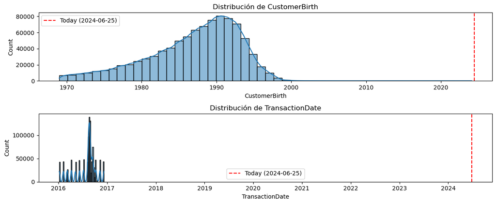

```python
# Configurar la fecha de hoy
today = pd.Timestamp(datetime.now().date())

# Verificar cuántas fechas son superiores a hoy
num_invalid_birthdates = df_transactions['CustomerBirth'][df_transactions['CustomerBirth'] > today].count()
print(f"Número de personas con una fecha de nacimiento superior a hoy: {num_invalid_birthdates}")

# Convertir las fechas mayores a hoy en NaN
df_transactions.loc[df_transactions['CustomerBirth'] > today, 'CustomerBirth'] = pd.NaT

# Verificar el número de nulos después del ajuste
null_after_adjustment = df_transactions['CustomerBirth'].isnull().sum()
print(f"Número de valores nulos después del ajuste: {null_after_adjustment}")

# Validar suma esperada de nulos
expected_nulls = null_after_conversion + num_invalid_birthdates
print(f"Suma esperada de valores nulos: {expected_nulls}")

# Asegurarse de que TransactionDate también es del tipo datetime
df_transactions['TransactionDate'] = pd.to_datetime(df_transactions['TransactionDate'], errors='coerce')

# Crear gráficos para la visualización
fig, axs = plt.subplots(2, 1, figsize=(12, 5))

# Histograma y KDE para CustomerBirth
sns.histplot(df_transactions['CustomerBirth'].dropna(), kde=True, ax=axs[0], bins=50)
axs[0].axvline(today, color='red', linestyle='--', label=f'Today ({today.date()})')
axs[0].set_title('Distribución de CustomerBirth')
axs[0].set_xlabel('CustomerBirth')
axs[0].set_ylabel('Count')
axs[0].legend()

# Histograma y KDE para TransactionDate
sns.histplot(df_transactions['TransactionDate'].dropna(), kde=True, ax=axs[1], bins=50)
axs[1].axvline(today, color='red', linestyle='--', label=f'Today ({today.date()})')
axs[1].set_title('Distribución de TransactionDate')
axs[1].set_xlabel('TransactionDate')
axs[1].set_ylabel('Count')
axs[1].legend()

plt.tight_layout()
plt.show()
```

- Habían algunos valores en la columna CustomerBirth que eran **1/1/1800** o **nan**, y estos valores están siendo convertidos a NaT (Not a Time) cuando se convierte la columna a tipo datetime. Esto ha causado que más valores se conviertan en nulos después de la conversión.
- Hemos imputado fechas futuras al día de hoy que no tiene sentido para estos datos; para manejar las fechas erróneas sin afectar los cálculos o análisis posteriores, una estrategia es dejar las fechas erróneas como valores nulos (NaN), esto permite que las herramientas de análisis y machine learning manejen estas entradas de manera adecuada. Además podemos ver que las fechas de las transacciones se reducen al año 2016.

Guardo los DataFrames en archivos CSV

```python
# Guardar los DataFrames en archivos CSV sin perder los índices
df_transactions.to_csv('data/clean/df_transactions.csv', index=True)
print("df_transactions.csv guardadado correctamente")

df_transactions_ = pd.read_csv('data/clean/df_transactions.csv', index_col=0)
print("df_transactions_.csv cargado correctamente")
```

```
df_transactions.csv guardadado correctamente
df_transactions_.csv cargado correctamente
```

```python
df_transactions_.head()
```

|  | TransactionID | CustomerID | CustomerBirth | CustomerGender | TransactionLocation | TransactionDate | TransactionAmount (eur) | EmitterID | ReceiverID |
| --- | --- | --- | --- | --- | --- | --- | --- | --- | --- |
| 0 | T1 | C5841053 | 1994-01-10 | F | Viana do Castelo | 2016-02-08 | 25.0 | C1419665 | C5841053 |
| 1 | T2 | C2142763 | NaN | M | Coria del Río | 2016-02-08 | 27999.0 | Unknown | C2142763 |
| 2 | T3 | C4417068 | 1996-11-26 | F | Jávea | 2016-02-08 | 459.0 | C3467392 | C4417068 |
| 3 | T4 | C5342380 | 1973-09-14 | F | Córdoba | 2016-02-08 | 2060.0 | C6628470 | C5342380 |
| 4 | T5 | C9031234 | 1988-03-24 | F | Sestao | 2016-02-08 | 1762.5 | C7321714 | C9031234 |

**Variables Explicativas (Features)**

Fraud Detection:

- **amount**: Monto de la transacción.
- **oldbalanceOrig**: Saldo original antes de la transacción.
- **newbalanceOrig**: Saldo nuevo después de la transacción.
- **oldbalanceDest**: Saldo original del destinatario antes de la transacción.
- **newbalanceDest**: Saldo nuevo del destinatario después de la transacción.
- **type**: Tipo de transacción (PAYMENT, TRANSFER, CASH_OUT).

**Variables Objetivo (Targets)**

Fraud Detection:

- **isFraud**: Indicador si la transacción es fraudulenta o no.

```python
df_fraud_detection.shape
```

```
(100000, 9)
```

### Análisis de las Variables Clave

**data_BOC_transactions.csv**

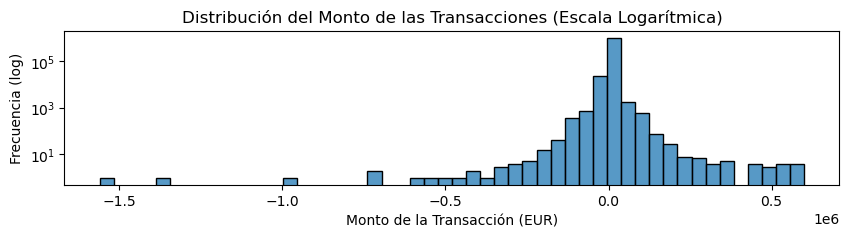

[figure not shown]

```python
# Histograma con escala logarítmica
plt.figure(figsize=(10, 2))
sns.histplot(df_transactions['TransactionAmount (eur)'], bins=50)
plt.yscale('log')
plt.title('Distribución del Monto de las Transacciones (Escala Logarítmica)')
plt.xlabel('Monto de la Transacción (EUR)')
plt.ylabel('Frecuencia (log)')
plt.show()

# Análisis de CustomerGender
plt.figure(figsize=(6, 2))
sns.countplot(data=df_transactions, x='CustomerGender')
plt.title('Distribución de Género de los Clientes')
plt.xlabel('Género')
plt.ylabel('Frecuencia')
plt.show()
```

- **Distribución del Monto de las Transacciones (Escala Logarítmica):** La mayoría de las transacciones tienen montos pequeños con algunos valores extremos. La transformación logarítmica ayuda a estabilizar la varianza y normalizar la distribución, lo que puede mejorar el rendimiento de los algoritmos de ML que asumen una distribución normal de los datos.
- **Distribución de Género de los Clientes:** La predominancia de clientes masculinos indica una posible variable predictiva demográfica. Esta distribución de género puede ser útil para segmentar los datos y entender mejor los patrones de comportamiento de diferentes grupos de clientes.

**data_BOC_creditRisk.csv**

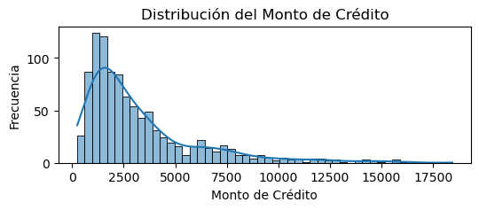

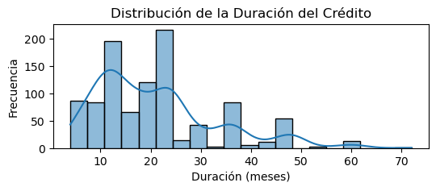

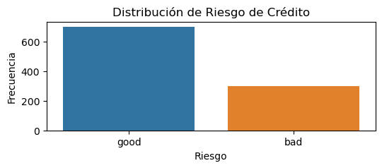

```python
# Análisis de la cantidad de crédito y la duración
plt.figure(figsize=(6, 2))
sns.histplot(df_credit_risk['Credit amount'], bins=50, kde=True)
plt.title('Distribución del Monto de Crédito')
plt.xlabel('Monto de Crédito')
plt.ylabel('Frecuencia')
plt.show()

plt.figure(figsize=(6, 2))
sns.histplot(df_credit_risk['Duration'], bins=20, kde=True)
plt.title('Distribución de la Duración del Crédito')
plt.xlabel('Duración (meses)')
plt.ylabel('Frecuencia')
plt.show()

# Distribución del riesgo
plt.figure(figsize=(6, 2))
sns.countplot(data=df_credit_risk, x='Risk')
plt.title('Distribución de Riesgo de Crédito')
plt.xlabel('Riesgo')
plt.ylabel('Frecuencia')
plt.show()
```

- **Distribución del Monto de Crédito**: La mayoría de los créditos tienen montos pequeños, lo cual puede influir en la predicción del riesgo crediticio. La distribución sesgada hacia montos más bajos sugiere que el modelo debe estar bien ajustado para manejar esta variabilidad y detectar patrones tanto en créditos pequeños como en los pocos créditos de montos altos.
- **Distribución de la Duración del Crédito**: La concentración de créditos en duraciones cortas (10-24 meses) sugiere que el modelo debe ser capaz de distinguir entre diferentes comportamientos de pago a corto plazo. Las duraciones más largas, aunque menos frecuentes, pueden proporcionar información valiosa sobre los clientes con créditos de mayor plazo.
- **Distribución de Riesgo de Crédito**: La mayoría de los clientes tienen un buen riesgo de crédito, indicando un desequilibrio de clases en el dataset. Para construir un modelo robusto, se necesitarán técnicas como el sobremuestreo (SMOTE) o el submuestreo para manejar este desequilibrio y asegurar que el modelo no sea sesgado hacia la clase mayoritaria (buen riesgo).

**data_BOC_fraudDetection.csv**

```python
df_fraud_detection.info()
```

```
<class 'pandas.core.frame.DataFrame'>
RangeIndex: 100000 entries, 0 to 99999
Data columns (total 9 columns):
 #   Column          Non-Null Count   Dtype
---  ------          --------------   -----
 0   type            100000 non-null  object
 1   amount          100000 non-null  float64
 2   Orig            75000 non-null   object
 3   oldbalanceOrig  100000 non-null  float64
 4   newbalanceOrig  100000 non-null  float64
 5   Dest            75000 non-null   object
 6   oldbalanceDest  100000 non-null  float64
 7   newbalanceDest  100000 non-null  float64
 8   isFraud         100000 non-null  int64
dtypes: float64(5), int64(1), object(3)
memory usage: 6.9+ MB
```

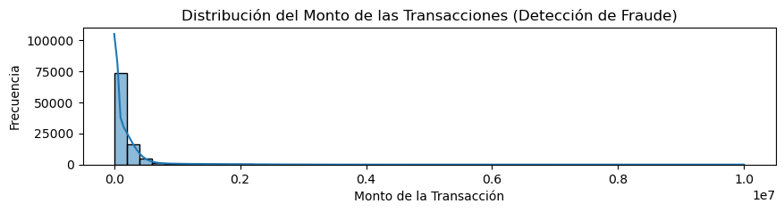

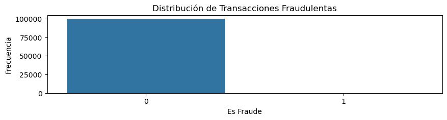

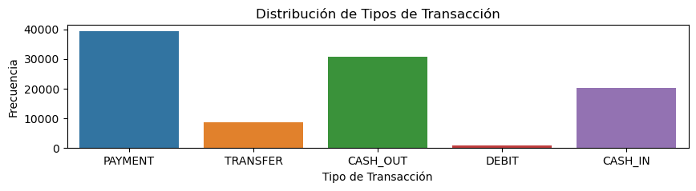

```python
# Distribución de los montos de las transacciones
plt.figure(figsize=(10, 2))
sns.histplot(df_fraud_detection['amount'], bins=50, kde=True)
plt.title('Distribución del Monto de las Transacciones (Detección de Fraude)')
plt.xlabel('Monto de la Transacción')
plt.ylabel('Frecuencia')
plt.show()

# Distribución de las transacciones fraudulentas
plt.figure(figsize=(10, 2))
sns.countplot(data=fraud_detection, x='isFraud')
plt.title('Distribución de Transacciones Fraudulentas')
plt.xlabel('Es Fraude')
plt.ylabel('Frecuencia')
plt.show()

# Análisis de la distribución de tipo de transacción
plt.figure(figsize=(10, 2))
sns.countplot(data=fraud_detection, x='type')
plt.title('Distribución de Tipos de Transacción')
plt.xlabel('Tipo de Transacción')
plt.ylabel('Frecuencia')
plt.show()
```

- **Distribución del Monto de las Transacciones:** La mayoría de las transacciones tienen montos pequeños, pero las transacciones fraudulentas pueden tener montos significativamente diferentes. La identificación de transacciones anómalas en diferentes rangos de montos será crucial para un modelo efectivo de detección de fraude.
- **Distribución de Transacciones Fraudulentas:** La baja incidencia de transacciones fraudulentas representa un gran desequilibrio de clases. Técnicas de re-muestreo, como SMOTE, y el uso de métricas de evaluación como el F1-score, en lugar de la precisión, serán cruciales para evaluar el rendimiento del modelo.
- **Distribución de Tipos de Transacción:** La alta frecuencia de ciertos tipos de transacción (como "PAYMENT" y "CASH_OUT") indica que el modelo debe ser capaz de identificar patrones de fraude específicos para estos tipos de transacción. La variabilidad en los tipos de transacciones también puede ayudar a mejorar la precisión del modelo al capturar características específicas de cada tipo.